# AllLife Credit Card Customer Segmentation

## Background:

AllLife Bank wants to focus on its credit card customer base in the next financial year. They have been advised by their marketing research team, that the penetration in the market can be improved.  
Based on this input, the Marketing team proposes to run personalized campaigns to target new customers as well as up sell to existing customers. Another insight from the market research was that the customers perceive the support services of the bank poorly. Based on this, the Operations team wants to upgrade the service delivery model, to ensure that customers queries are resolved faster. Head of Marketing and Head of Delivery both decide to reach out to the Data Science team for help.

## Objective:

To identify different segments in the existing customer based on their spending patterns as well as past interaction with the bank.

## Key Questions:

1. How many different segments of customers are there?
2. How are these segments different from each other?
3. What are your recommendations to the bank on how to better market to and service these customers?

## Data Description:

Data is of various customers of a bank with their credit limit, the total number of credit cards the customer has, and different channels through which customer has contacted the bank for any queries, different channels include visiting the bank, online and through a call centre.

## https://github.com/GreatLearningAIML1/gl-pgp-aiml-uta-intl-apr20-SubratMuruni.git

```python
# Import all essential python libraries

import numpy as np # importing Numpy
import pandas as pd # importing Pandas
import scipy.stats as stats # importing Scipy for statistical operations
import matplotlib.pyplot as plt # importing Matplotlib
import seaborn as sns # importing Seaborn
sns.set(color_codes = True) # setting the background of the visualization graph
%matplotlib inline
import warnings
warnings.filterwarnings('ignore')
from scipy.stats import zscore # importing zscore for scaling
from sklearn import metrics # importing metrics for calculating the scores
from sklearn.cluster import KMeans # importing Kmeans algorithm from cluster
from sklearn.decomposition import PCA # importing principal component analysis from decomposition
```

## Deliverable – 1: Univariate analysis (10 marks)

Perform univariate analysis on the data to better understand the variables at your disposal and to get an idea about the no of clusters. Perform EDA, create visualizations to explore data.

**1.1 General characteristic of the dataset**

```python
# read the dataset into a dataframe
dfBankCustBase =  pd.read_excel(
    '/Users/subratmuruni/desktop/Data Science/Projects_Assignments/Project_dataset/Credit Card Customer Data.xlsx',
sheet_name = 'Sheet1')
```

```python
# read the first 5 rows of the dataset
dfBankCustBase.head() # there are no dependent variables in this dataset. it's a clustering problem
```

|  | Sl_No | Customer Key | Avg_Credit_Limit | Total_Credit_Cards | Total_visits_bank | Total_visits_online | Total_calls_made |
| --- | --- | --- | --- | --- | --- | --- | --- |
| 0 | 1 | 87073 | 100000 | 2 | 1 | 1 | 0 |
| 1 | 2 | 38414 | 50000 | 3 | 0 | 10 | 9 |
| 2 | 3 | 17341 | 50000 | 7 | 1 | 3 | 4 |
| 3 | 4 | 40496 | 30000 | 5 | 1 | 1 | 4 |
| 4 | 5 | 47437 | 100000 | 6 | 0 | 12 | 3 |

```python
# read the last 5 rows of the dataset
dfBankCustBase.tail()
```

|  | Sl_No | Customer Key | Avg_Credit_Limit | Total_Credit_Cards | Total_visits_bank | Total_visits_online | Total_calls_made |
| --- | --- | --- | --- | --- | --- | --- | --- |
| 655 | 656 | 51108 | 99000 | 10 | 1 | 10 | 0 |
| 656 | 657 | 60732 | 84000 | 10 | 1 | 13 | 2 |
| 657 | 658 | 53834 | 145000 | 8 | 1 | 9 | 1 |
| 658 | 659 | 80655 | 172000 | 10 | 1 | 15 | 0 |
| 659 | 660 | 80150 | 167000 | 9 | 0 | 12 | 2 |

```python
# find the rows and columns of the dataframe
dfBankCustBase.shape # dataset has 660 rows and 7 columns
```

```
(660, 7)
```

```python
# columns of the dataset
col = dfBankCustBase.columns
col
```

```
Index(['Sl_No', 'Customer Key', 'Avg_Credit_Limit', 'Total_Credit_Cards',
       'Total_visits_bank', 'Total_visits_online', 'Total_calls_made'],
      dtype='object')
```

```python
# information of the dataset with regards to columns, count and datatype
dfBankCustBase.info() # indicates 7 columns with int datatype
```

```
<class 'pandas.core.frame.DataFrame'>
RangeIndex: 660 entries, 0 to 659
Data columns (total 7 columns):
 #   Column               Non-Null Count  Dtype
---  ------               --------------  -----
 0   Sl_No                660 non-null    int64
 1   Customer Key         660 non-null    int64
 2   Avg_Credit_Limit     660 non-null    int64
 3   Total_Credit_Cards   660 non-null    int64
 4   Total_visits_bank    660 non-null    int64
 5   Total_visits_online  660 non-null    int64
 6   Total_calls_made     660 non-null    int64
dtypes: int64(7)
memory usage: 36.2 KB
```

**1.2 Datatype, Central Value, IQR, standard Deviation**

```python
# datatype of the columns of the dataset
dfBankCustBase.dtypes # there are 7 columns that are of int64 datatype
```

```
Sl_No                  int64
Customer Key           int64
Avg_Credit_Limit       int64
Total_Credit_Cards     int64
Total_visits_bank      int64
Total_visits_online    int64
Total_calls_made       int64
dtype: object
```

```python
# find the mean of the columns of the dataset
dfBankCustBase.mean() # provides mean of the continuous variables
```

```
Sl_No                    330.500000
Customer Key           55141.443939
Avg_Credit_Limit       34574.242424
Total_Credit_Cards         4.706061
Total_visits_bank          2.403030
Total_visits_online        2.606061
Total_calls_made           3.583333
dtype: float64
```

```python
# find the median of the columns of the dataset
dfBankCustBase.median() # provides median of the continuous variables
```

```
Sl_No                    330.5
Customer Key           53874.5
Avg_Credit_Limit       18000.0
Total_Credit_Cards         5.0
Total_visits_bank          2.0
Total_visits_online        2.0
Total_calls_made           3.0
dtype: float64
```

```python
# find the mode of the columns of the dataset
dfBankCustBase_1 = dfBankCustBase.drop('Sl_No',axis=1) # dropping the Sl_No column

dfBankCustBase_1.mode() # provides mode of the continuous variables
```

|  | Customer Key | Avg_Credit_Limit | Total_Credit_Cards | Total_visits_bank | Total_visits_online | Total_calls_made |
| --- | --- | --- | --- | --- | --- | --- |
| 0 | 37252 | 8000.0 | 4.0 | 2.0 | 2.0 | 4.0 |
| 1 | 47437 | NaN | NaN | NaN | NaN | NaN |
| 2 | 50706 | NaN | NaN | NaN | NaN | NaN |
| 3 | 96929 | NaN | NaN | NaN | NaN | NaN |
| 4 | 97935 | NaN | NaN | NaN | NaN | NaN |

**The repetition of Customer Key indicated that there are 5 repeating customer key values. Further investigation need to be done to find out if there are duplicate rows in the dataframe.**

```python
# find the standard deviation of the continuous variables
dfBankCustBase_1.std()
```

```
Customer Key           25627.772200
Avg_Credit_Limit       37625.487804
Total_Credit_Cards         2.167835
Total_visits_bank          1.631813
Total_visits_online        2.935724
Total_calls_made           2.865317
dtype: float64
```

```python
# find interquartile range of the dataset
Q1 = dfBankCustBase_1.quantile(0.25)
Q3 = dfBankCustBase_1.quantile(0.75)
IQR = Q3 - Q1
IQR # gives the IQR of continuous variables
```

```
Customer Key           43377.25
Avg_Credit_Limit       38000.00
Total_Credit_Cards         3.00
Total_visits_bank          3.00
Total_visits_online        3.00
Total_calls_made           4.00
dtype: float64
```

**1.3 Missing values, Null values and incorrect imputation**

```python
# check the missing values/null in the dataset
dfBankCustBase.isnull().sum() # there are no missing values and null values in the dataset
```

```
Sl_No                  0
Customer Key           0
Avg_Credit_Limit       0
Total_Credit_Cards     0
Total_visits_bank      0
Total_visits_online    0
Total_calls_made       0
dtype: int64
```

```python
# find null values in the dataset
dfBankCustBase.isnull().any() # all columns indicate false which means no missing values
```

```
Sl_No                  False
Customer Key           False
Avg_Credit_Limit       False
Total_Credit_Cards     False
Total_visits_bank      False
Total_visits_online    False
Total_calls_made       False
dtype: bool
```

```python
# check for values that are NaN/NA
dfBankCustBase.isna().sum() # there are no values as Na or NaN
```

```
Sl_No                  0
Customer Key           0
Avg_Credit_Limit       0
Total_Credit_Cards     0
Total_visits_bank      0
Total_visits_online    0
Total_calls_made       0
dtype: int64
```

```python
# find NaN/NA or improper values in the dataset
dfBankCustBase.isna().any() # false indicates no Na or NaN values in the dataset
```

```
Sl_No                  False
Customer Key           False
Avg_Credit_Limit       False
Total_Credit_Cards     False
Total_visits_bank      False
Total_visits_online    False
Total_calls_made       False
dtype: bool
```

```python
# find duplicates in the dataset
dfBankCustBase.duplicated().sum() # there are 0 duplicate rows in the dataframe
```

```
0
```

**The duplicate analysis indicates that although 5 customer key values are repeated but the other columns associated with these repeated customer keys are not exactly the same.**

```python
# find the rows that have duplicate customer key
dfBankCustBase.loc[dfBankCustBase['Customer Key'].isin([37252,47437,50706,96929,97935])].sort_values(['Customer Key'])
```

|  | Sl_No | Customer Key | Avg_Credit_Limit | Total_Credit_Cards | Total_visits_bank | Total_visits_online | Total_calls_made |
| --- | --- | --- | --- | --- | --- | --- | --- |
| 48 | 49 | 37252 | 6000 | 4 | 0 | 2 | 8 |
| 432 | 433 | 37252 | 59000 | 6 | 2 | 1 | 2 |
| 4 | 5 | 47437 | 100000 | 6 | 0 | 12 | 3 |
| 332 | 333 | 47437 | 17000 | 7 | 3 | 1 | 0 |
| 411 | 412 | 50706 | 44000 | 4 | 5 | 0 | 2 |
| 541 | 542 | 50706 | 60000 | 7 | 5 | 2 | 2 |
| 391 | 392 | 96929 | 13000 | 4 | 5 | 0 | 0 |
| 398 | 399 | 96929 | 67000 | 6 | 2 | 2 | 2 |
| 104 | 105 | 97935 | 17000 | 2 | 1 | 2 | 10 |
| 632 | 633 | 97935 | 187000 | 7 | 1 | 7 | 0 |

```python
# find whether all values in columns are real or not
dfBankCustBase[~dfBankCustBase.applymap(np.isreal).all(1)] # results show that all are real values
```

|  | Sl_No | Customer Key | Avg_Credit_Limit | Total_Credit_Cards | Total_visits_bank | Total_visits_online | Total_calls_made |
| --- | --- | --- | --- | --- | --- | --- | --- |

```python
# find the unique values of variables
dfBankCustBase.nunique() # indicates that there are a lot of discrete values in the columns
```

```
Sl_No                  660
Customer Key           655
Avg_Credit_Limit       110
Total_Credit_Cards      10
Total_visits_bank        6
Total_visits_online     16
Total_calls_made        11
dtype: int64
```

```python
# drop multiple entry rows of the customer key from dfBankCustBase_1 w.r.t to lower credit limit
dfBankCustBase_1.drop([48,332,411,391,104],axis=0, inplace=True)
```

```python
# check that the rows with higher credit limit are retained
dfBankCustBase_1.loc[dfBankCustBase['Customer Key'].isin([37252,
                                                          47437,
                                                          50706,
                                                          96929,
                                                          97935])].sort_values(['Customer Key'])
```

|  | Customer Key | Avg_Credit_Limit | Total_Credit_Cards | Total_visits_bank | Total_visits_online | Total_calls_made |
| --- | --- | --- | --- | --- | --- | --- |
| 432 | 37252 | 59000 | 6 | 2 | 1 | 2 |
| 4 | 47437 | 100000 | 6 | 0 | 12 | 3 |
| 541 | 50706 | 60000 | 7 | 5 | 2 | 2 |
| 398 | 96929 | 67000 | 6 | 2 | 2 | 2 |
| 632 | 97935 | 187000 | 7 | 1 | 7 | 0 |

```python
# describe the summary of the dataframe
dfBankCustBase_2 = dfBankCustBase_1.drop('Customer Key',axis=1) # dropping the Customer Key column

dfBankCustBase_2.describe().T
```

|  | count | mean | std | min | 25% | 50% | 75% | max |
| --- | --- | --- | --- | --- | --- | --- | --- | --- |
| Avg_Credit_Limit | 655.0 | 34690.076336 | 37728.591465 | 3000.0 | 10000.0 | 18000.0 | 48500.0 | 200000.0 |
| Total_Credit_Cards | 655.0 | 4.709924 | 2.171150 | 1.0 | 3.0 | 5.0 | 6.0 | 10.0 |
| Total_visits_bank | 655.0 | 2.400000 | 1.627929 | 0.0 | 1.0 | 2.0 | 4.0 | 5.0 |
| Total_visits_online | 655.0 | 2.618321 | 2.942512 | 0.0 | 1.0 | 2.0 | 4.0 | 15.0 |
| Total_calls_made | 655.0 | 3.580153 | 2.852528 | 0.0 | 1.0 | 3.0 | 5.0 | 10.0 |

```python
# check the skewness of the continuous variables
dfBankCustBase.skew()
```

```
Sl_No                  0.000000
Customer Key           0.051462
Avg_Credit_Limit       2.202396
Total_Credit_Cards     0.144879
Total_visits_bank      0.141896
Total_visits_online    2.225607
Total_calls_made       0.658905
dtype: float64
```

**1.4 Univariate Analysis: Histogram plots for the variables in the dataframe**

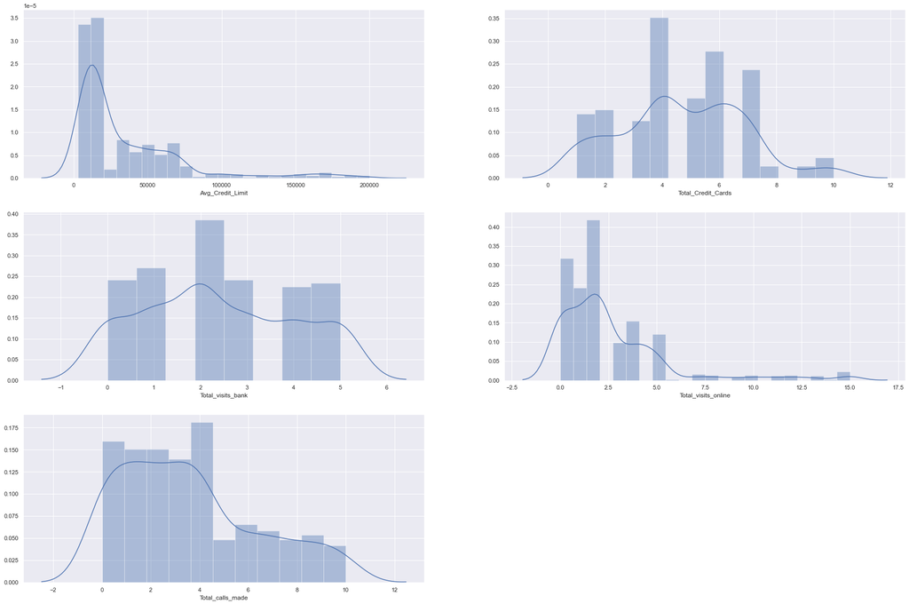

```python
# plot distplot for the continuous variables
plt.figure(figsize=(30,20))
pos = 1
columns = dfBankCustBase_2.columns

for i in columns:
    plt.subplot(3,2,pos)
    sns.distplot(dfBankCustBase_2[i],kde=True)
    # plt.legend().remove()
    pos += 1
plt.show();
```

**1.5 Univariate Analysis: Box plots for the variables in the dataframe**

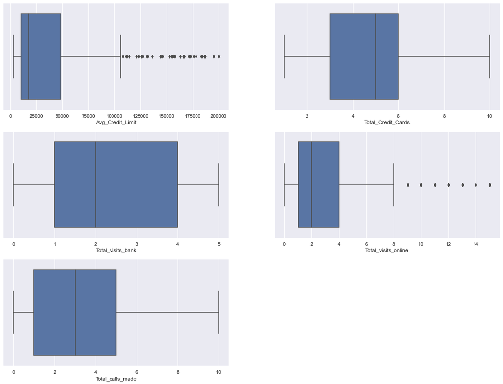

```python
# plot boxplot for the continuous variables
plt.figure(figsize=(20,15))
pos = 1
columns = dfBankCustBase_2.columns

for i in columns:
    plt.subplot(3,2,pos)
    sns.boxplot(x = dfBankCustBase_2[i])
    # plt.legend().remove()
    pos += 1
plt.show();
```

**1.6 Correlation Matrix of the variables**

```python
# correlation between attributes
corr = dfBankCustBase_2.corr() # assigning variable corr as the correlation function output

corr
```

|  | Avg_Credit_Limit | Total_Credit_Cards | Total_visits_bank | Total_visits_online | Total_calls_made |
| --- | --- | --- | --- | --- | --- |
| Avg_Credit_Limit | 1.000000 | 0.610227 | -0.102314 | 0.551581 | -0.416628 |
| Total_Credit_Cards | 0.610227 | 1.000000 | 0.317103 | 0.167892 | -0.651979 |
| Total_visits_bank | -0.102314 | 0.317103 | 1.000000 | -0.552223 | -0.501813 |
| Total_visits_online | 0.551581 | 0.167892 | -0.552223 | 1.000000 | 0.126250 |
| Total_calls_made | -0.416628 | -0.651979 | -0.501813 | 0.126250 | 1.000000 |

**1.7 Heatmap between variables**

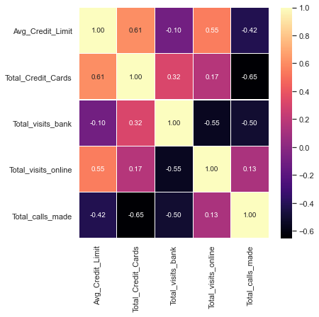

```python
# plot heatmap for the correlation between variables
plt.figure(figsize=(6,6))

sns.heatmap(corr, annot=True, linewidth=0.05, fmt='0.2f',cmap ='magma');
plt.show()
```

**1.8 Pair plot between variables**

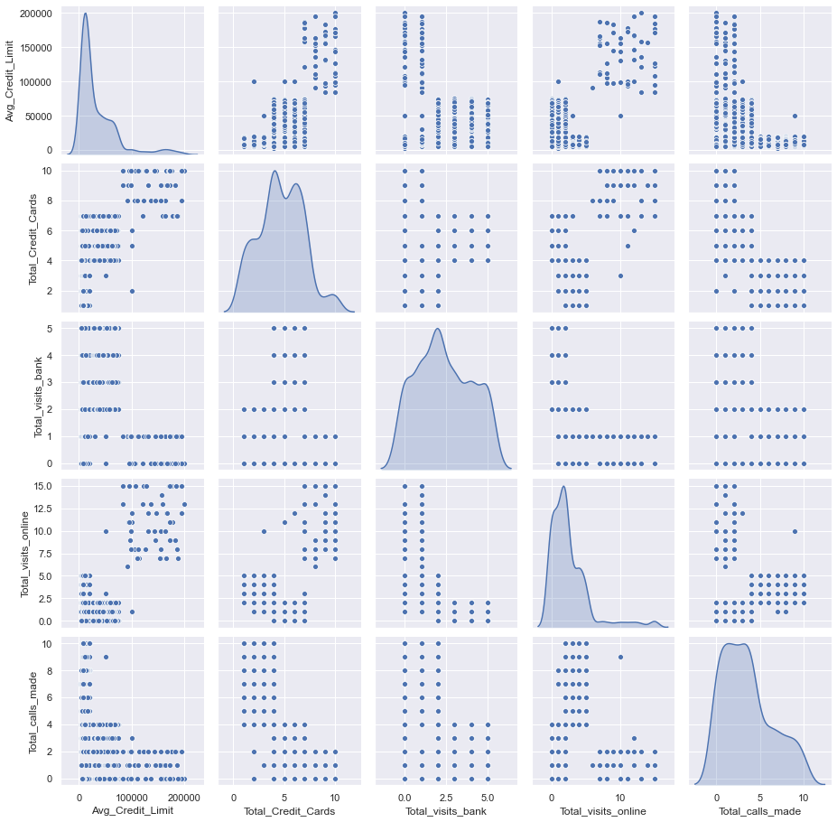

```python
# plot the pairplot between variables with diagonal as KDE
plt.figure(figsize=(8,8))
sns.pairplot(dfBankCustBase_2, diag_kind='kde')
plt.show();
```

## Deliverable – 2: Insights from graphs (5 marks)

Properly comment on the codes, provide explanations of the steps taken in the notebook and conclude your insights from the graphs.

**2.1 Insights from the graphs**

1. The variables are in different scales. So scaling is needed for unsupervised learning
2. Checking the Mode indicates that some customer keys are repeated. These are not duplicate in the true sense because the other values are different.
3. The credit limit of the repeated customer key is checked and the rows with higher credit limit is retained assuming that there was an credit limit increase for these customer.
4. Observing the KDE in the histogram indicates that the Agv_credit_limit and Total_visits_online are right skewed and may have outliers. So outliers treatment will be considering in data pre-processing
5. The Histogram shows that all the variables are not normally distributed.
6. Plotting boxplot shows that the Avg_credit_limit and the Total_visits_online have outliers. Outliers treatment for these two columns may be considered during pre-processing.
7. Since there are very few outliers in the Total_visits_online outliers treatment will be considered. We are not considering outliers treatment for Avg_credit_limit because the outliers are larger in number and will change the shape of the data if treated.
8. The heatmap shows that there is a strong positive correlation between the credit limit and number of credit cards held by a customer
9. The heatmap also tells us that online visitors tend to have more credit limit.
10. There is a strong negative correlation between the number of calls and the credit card held by customer and number of calls and average credit limit. This may imply the the poor customer service faced by customers with more credit cards.
11. Communication based mode of contact (Phone call or Online) shows a negative correlation with the direct visit to bank.
12. Pair plot between variables indicates somewhat linear relationship between average credit limit and total credit cards, between online visits and average credit limit, between total credit cards and total online visits  
    13.**Looking at the diagonal of the pair plot indicates that there may be at least 4 peaks amongst the data set which would imply the cluster value to be at least 3 or 4.**
13. Data transformation may be also contemplated to treat skewness of data.
14. Dimensionality reduction may not be needed with the dataset

**2.2 Data Preprocessing**

**2.2.1 Scaling Data**

```python
# scale the data using zscore
dfScaled = dfBankCustBase_2.apply(zscore)
```

```python
# check the resulting dataframe
dfScaled.head()
```

|  | Avg_Credit_Limit | Total_Credit_Cards | Total_visits_bank | Total_visits_online | Total_calls_made |
| --- | --- | --- | --- | --- | --- |
| 0 | 1.732369 | -1.249105 | -0.860646 | -0.550400 | -1.256040 |
| 1 | 0.406101 | -0.788168 | -1.475392 | 2.510549 | 1.901468 |
| 2 | 0.406101 | 1.055582 | -0.860646 | 0.129811 | 0.147297 |
| 3 | -0.124406 | 0.133707 | -0.860646 | -0.550400 | 0.147297 |
| 4 | 1.732369 | 0.594644 | -1.475392 | 3.190759 | -0.203537 |

```python
# copy the dataframe to use for hierarchical clustering
dfScaled_1 = dfScaled.copy()
```

**2.2.2 Outliers treated, transformed and Scaling Data**

```python
# we will do outliers treatment for only total_visits_online as Avg_Credit_Limit has too many outliers
# since a majority of the outliers are close to the whiskes, cap them with whiskers as the range
# finding interquartile range of the dataset
Q1 = dfBankCustBase_2['Total_visits_online'].quantile(0.25)
Q3 = dfBankCustBase_2['Total_visits_online'].quantile(0.75)
IQR = Q3- Q1
IQR # gives the IQR of continuous variables

# find variables which are ouside the wishkers of the IQR
np.where((dfBankCustBase_2['Total_visits_online'] < (Q1- 1.5*IQR)) |
         (dfBankCustBase_2['Total_visits_online'] > (Q3 + 1.5*IQR)))
```

```
(array([  1,   4,   6, 607, 608, 610, 611, 612, 613, 614, 615, 616, 617,
        619, 621, 622, 623, 625, 626, 628, 632, 634, 635, 636, 637, 639,
        640, 642, 645, 646, 648, 649, 650, 651, 652, 653, 654]),)
```

```python
# copy the original dataframe into a new dataframe for treating outliers
dfOutlier = dfBankCustBase_2.copy()

# replace every outlier on the lower side by the lower whisker
for i in zip(np.where(dfOutlier['Total_visits_online'] < Q1 - 1.5*IQR)):
    whisker = Q1 - 1.5*IQR
    dfOutlier['Total_visits_online'].iloc[i] = whisker

# replace every outlier on the upper side by the upper whisker
for i in zip(np.where(dfOutlier['Total_visits_online'] > Q3 + 1.5*IQR)):
    whisker = Q3 + 1.5*IQR
    dfOutlier['Total_visits_online'].iloc[i] = whisker
```

```python
# apply log transformation on the data that are heavily skewed
columns = ['Total_visits_online','Total_calls_made']
for col in columns:
    dfOutlier[col] = np.log(dfOutlier[col]+1)

dfOutlier['Avg_Credit_Limit'] = np.log(dfOutlier['Avg_Credit_Limit'])

dfOutlier.skew() # check skewness of data
```

```
Avg_Credit_Limit       0.390699
Total_Credit_Cards     0.141287
Total_visits_bank      0.142998
Total_visits_online   -0.086541
Total_calls_made      -0.429483
dtype: float64
```

```python
# scale data using zscore
dfTransformed = dfOutlier.apply(zscore)

dfTransformed.head()
```

|  | Avg_Credit_Limit | Total_Credit_Cards | Total_visits_bank | Total_visits_online | Total_calls_made |
| --- | --- | --- | --- | --- | --- |
| 0 | 1.625283 | -1.249105 | -0.860646 | -0.472925 | -1.801240 |
| 1 | 0.881343 | -0.788168 | -1.475392 | 1.846716 | 1.401860 |
| 2 | 0.881343 | 1.055582 | -0.860646 | 0.558977 | 0.437630 |
| 3 | 0.333084 | 0.133707 | -0.860646 | -0.472925 | 0.437630 |
| 4 | 1.625283 | 0.594644 | -1.475392 | 1.846716 | 0.127218 |

```python
# copy the dataframe to use for hierarchical clustering
dfTransformed_1 = dfTransformed.copy()
```

**2.2.3 PCA Data**

1. Scale the data
2. Find the Covariance Matrix
3. Find the Eigen Values and Eigen Vectors
4. Calculate Cumulative Variance and Find out optimum number of transformed variables
5. Refit with the transformed variables

```python
# use the scaled data and find covariance matrix
covmatrix = np.cov(dfScaled,rowvar=False)
print(covmatrix)
```

```
[[ 1.00152905  0.61116027 -0.10247087  0.55242398 -0.41726498]
 [ 0.61116027  1.00152905  0.3175883   0.16814871 -0.65297544]
 [-0.10247087  0.3175883   1.00152905 -0.55306749 -0.50258027]
 [ 0.55242398  0.16814871 -0.55306749  1.00152905  0.126443  ]
 [-0.41726498 -0.65297544 -0.50258027  0.126443    1.00152905]]
```

```python
# use PCA from sklearn to fit the scaled data
pca = PCA(n_components=5) # use all the 5 variables to find the variation explained by each variable
pca.fit(dfScaled)
```

```
PCA(n_components=5)
```

```python
# find the variance and Eigen vectors
print(pca.explained_variance_)
print()
print(pca.explained_variance_ratio_)
print()
print(pca.components_)
```

```
[2.29159234 1.87366916 0.3236732  0.27545246 0.2432581 ]

[0.45761874 0.37416172 0.06463581 0.05500638 0.04857734]

[[ 0.49124322  0.59815604  0.27620807  0.11522029 -0.55796311]
 [ 0.40017085  0.02542796 -0.58896899  0.66452658  0.22524799]
 [ 0.00956506 -0.29168043 -0.60960535 -0.30791422 -0.66962764]
 [ 0.29863099 -0.73728301  0.45118241  0.32836352 -0.23631575]
 [-0.71363256  0.11357405  0.0405016   0.58523067 -0.36564216]]
```

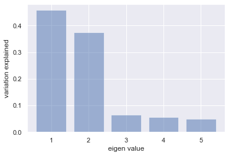

```python
# plot the graph to explain the variance by each variable
plt.bar(list(range(1,6)),pca.explained_variance_ratio_, alpha=0.5,align='center')
plt.ylabel('variation explained')
plt.xlabel('eigen value')
plt.show();
```

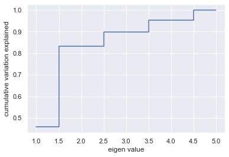

```python
# plot the cumulative sum of variance explained
plt.step(list(range(1,6)),np.cumsum(pca.explained_variance_ratio_), where='mid')
plt.ylabel('cumulative variation explained')
plt.xlabel('eigen value')
plt.show();
```

```python
# fit the scaled dataset and transform it
pca3 = PCA(n_components=3) # 90% of variance is explained by 3 components
pca3.fit(dfScaled)
pca3_transformed = pca3.transform(dfScaled)
```

```python
# convert the resulting array into a dataframe
df_pca = pd.DataFrame(pca3_transformed)
df_pca.head()
```

|  | 0 | 1 | 2 |
| --- | --- | --- | --- |
| 0 | 0.503544 | 0.519699 | 1.916119 |
| 1 | -1.451151 | 3.108057 | -0.913124 |
| 2 | 0.525951 | 0.815686 | 0.082041 |
| 3 | -0.364457 | 0.127933 | 0.555306 |
| 4 | 1.280396 | 3.651823 | -0.103655 |

```python
# copy the dataframe to use for hierarchical clustering
df_pca_1 = df_pca.copy()
```

## Deliverable – 3: K-Means clustering (10 marks)

Execute K-means clustering use elbow plot and analyse clusters using boxplot

**3.1 Number of clusters (K) for K-Means clustering**

1. Find the optimum K for the cluster formation
2. Use all the three datasets to find out the optimum K
3. Find the cluster labels and add to the dataset
4. Plot the boxplot of the clusters formed
5. Analyze the clusters formed by observing the boxplot

**3.1.1 K-Means clustering of scaled only dataset**

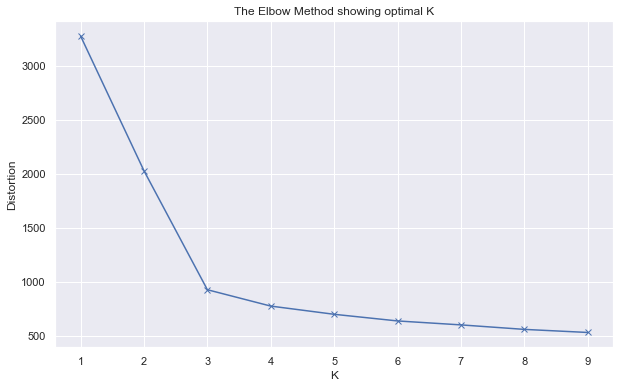

```python
# elbow method to find the optimal K for clustering on scaled only dataset
distortion =[] # within cluster variance
K = range(1,10) # k ranges for the elbow method

for k in K:
    kmeanModel = KMeans(n_clusters=k) # initiating KMeans algorithm
    kmeanModel.fit(dfScaled) # fit model to the scaled dataset
    distortion.append(kmeanModel.inertia_)# append within cluster variance value

# plot elbow
plt.figure(figsize=(10,6))
plt.plot(K,distortion,'bx-')
plt.xlabel('K')
plt.ylabel('Distortion')
plt.title('The Elbow Method showing optimal K')
plt.show();
```

**The Elbow method indicated that there are three (3) clusters**

```python
# take k=3 as the number of clusters
kmeansModel=KMeans(3)
kmeansModel.fit(dfScaled)
prediction=kmeansModel.predict(dfScaled)
```

```python
# find centroids of the clusters formed
centroids = kmeansModel.cluster_centers_
centroids
```

```
array([[-0.0221829 ,  0.37320193,  0.66578849, -0.55483952, -0.55070751],
       [-0.59708296, -1.06223867, -0.8994134 ,  0.32284397,  1.14764832],
       [ 2.82096934,  1.85761293, -1.10654432,  2.8166435 , -0.87713902]])
```

```python
# create a dataframe of the centroids of the clusters
centroid_df = pd.DataFrame(centroids, columns=list(dfScaled))
centroid_df
```

|  | Avg_Credit_Limit | Total_Credit_Cards | Total_visits_bank | Total_visits_online | Total_calls_made |
| --- | --- | --- | --- | --- | --- |
| 0 | -0.022183 | 0.373202 | 0.665788 | -0.554840 | -0.550708 |
| 1 | -0.597083 | -1.062239 | -0.899413 | 0.322844 | 1.147648 |
| 2 | 2.820969 | 1.857613 | -1.106544 | 2.816644 | -0.877139 |

```python
#Append the prediction
dfBankCustBase_1["Labels"] = prediction
dfScaled["Labels"] = prediction
print("Cluster labels Assigned : \n")
dfBankCustBase_1.head(10)
```

```
Cluster labels Assigned :
```

|  | Customer Key | Avg_Credit_Limit | Total_Credit_Cards | Total_visits_bank | Total_visits_online | Total_calls_made | Labels |
| --- | --- | --- | --- | --- | --- | --- | --- |
| 0 | 87073 | 100000 | 2 | 1 | 1 | 0 | 0 |
| 1 | 38414 | 50000 | 3 | 0 | 10 | 9 | 1 |
| 2 | 17341 | 50000 | 7 | 1 | 3 | 4 | 0 |
| 3 | 40496 | 30000 | 5 | 1 | 1 | 4 | 0 |
| 4 | 47437 | 100000 | 6 | 0 | 12 | 3 | 2 |
| 5 | 58634 | 20000 | 3 | 0 | 1 | 8 | 1 |
| 6 | 48370 | 100000 | 5 | 0 | 11 | 2 | 2 |
| 7 | 37376 | 15000 | 3 | 0 | 1 | 1 | 1 |
| 8 | 82490 | 5000 | 2 | 0 | 2 | 2 | 1 |
| 9 | 44770 | 3000 | 4 | 0 | 1 | 7 | 1 |

```python
# group the labels and check the mean of the group this should be similar to the centroids calculated
dfScaled.groupby('Labels').mean()
```

| Labels | Avg_Credit_Limit | Total_Credit_Cards | Total_visits_bank | Total_visits_online | Total_calls_made |
| --- | --- | --- | --- | --- | --- |
| 0 | -0.022183 | 0.373202 | 0.665788 | -0.554840 | -0.550708 |
| 1 | -0.597083 | -1.062239 | -0.899413 | 0.322844 | 1.147648 |
| 2 | 2.820969 | 1.857613 | -1.106544 | 2.816644 | -0.877139 |

```python
# check the labels of the clusters created
kmeansModel.labels_
```

```
array([0, 1, 0, 0, 2, 1, 2, 1, 1, 1, 1, 1, 1, 1, 1, 1, 1, 1, 1, 1, 1, 1,
       1, 1, 1, 1, 1, 1, 1, 1, 1, 1, 1, 1, 1, 1, 1, 1, 1, 1, 1, 1, 1, 1,
       1, 1, 1, 1, 1, 1, 1, 1, 1, 1, 1, 1, 1, 1, 1, 1, 1, 1, 1, 1, 1, 1,
       1, 1, 1, 1, 1, 1, 1, 1, 1, 1, 1, 1, 1, 1, 1, 1, 1, 1, 1, 1, 1, 1,
       1, 1, 1, 1, 1, 1, 1, 1, 1, 1, 1, 1, 1, 1, 1, 1, 1, 1, 1, 1, 1, 1,
       1, 1, 1, 1, 1, 1, 1, 1, 1, 1, 1, 1, 1, 1, 1, 1, 1, 1, 1, 1, 1, 1,
       1, 1, 1, 1, 1, 1, 1, 1, 1, 1, 1, 1, 1, 1, 1, 1, 1, 1, 1, 1, 1, 1,
       1, 1, 1, 1, 1, 1, 1, 1, 1, 1, 1, 1, 1, 1, 1, 1, 1, 1, 1, 1, 1, 1,
       1, 1, 1, 1, 1, 1, 1, 1, 1, 1, 1, 1, 1, 1, 1, 1, 1, 1, 1, 1, 1, 1,
       1, 1, 1, 1, 1, 1, 1, 1, 1, 1, 1, 1, 1, 1, 1, 1, 1, 1, 1, 1, 1, 1,
       1, 1, 1, 1, 1, 1, 0, 0, 0, 0, 0, 0, 0, 0, 0, 0, 0, 0, 0, 0, 0, 0,
       0, 0, 0, 0, 0, 0, 0, 0, 0, 0, 0, 0, 0, 0, 0, 0, 0, 0, 0, 0, 0, 0,
       0, 0, 0, 0, 0, 0, 0, 0, 0, 0, 0, 0, 0, 0, 0, 0, 0, 0, 0, 0, 0, 0,
       0, 0, 0, 0, 0, 0, 0, 0, 0, 0, 0, 0, 0, 0, 0, 0, 0, 0, 0, 0, 0, 0,
       0, 0, 0, 1, 0, 0, 0, 0, 0, 0, 0, 0, 0, 0, 0, 0, 0, 0, 0, 0, 0, 0,
       0, 0, 0, 0, 0, 0, 0, 0, 0, 0, 0, 0, 0, 0, 0, 0, 0, 0, 0, 0, 0, 0,
       0, 0, 0, 0, 0, 0, 0, 0, 0, 0, 0, 0, 0, 0, 0, 0, 0, 0, 0, 0, 0, 0,
       0, 0, 0, 0, 0, 0, 0, 0, 0, 0, 0, 0, 0, 0, 0, 0, 0, 0, 0, 0, 0, 0,
       0, 0, 0, 0, 0, 0, 0, 0, 0, 0, 0, 0, 0, 0, 0, 0, 0, 0, 0, 0, 0, 0,
       0, 0, 0, 0, 0, 0, 0, 0, 0, 0, 0, 0, 0, 0, 0, 0, 0, 0, 0, 0, 0, 0,
       0, 0, 0, 0, 0, 0, 0, 0, 0, 0, 0, 0, 0, 0, 0, 0, 0, 0, 0, 0, 0, 0,
       0, 0, 0, 0, 0, 0, 0, 0, 0, 0, 0, 0, 0, 0, 0, 0, 0, 0, 0, 0, 0, 0,
       0, 0, 0, 0, 0, 0, 0, 0, 0, 0, 0, 0, 0, 0, 0, 0, 0, 0, 0, 0, 0, 0,
       0, 0, 0, 0, 0, 0, 0, 0, 0, 0, 0, 0, 0, 0, 0, 0, 0, 0, 0, 0, 0, 0,
       0, 0, 0, 0, 0, 0, 0, 0, 0, 0, 0, 0, 0, 0, 0, 0, 0, 0, 0, 0, 0, 0,
       0, 0, 0, 0, 0, 0, 0, 0, 0, 0, 0, 0, 0, 0, 0, 0, 0, 0, 0, 0, 0, 0,
       0, 0, 0, 0, 0, 0, 0, 0, 0, 0, 0, 0, 0, 0, 0, 0, 0, 0, 0, 0, 0, 0,
       0, 0, 0, 0, 0, 0, 0, 0, 0, 0, 0, 0, 0, 2, 2, 2, 2, 2, 2, 2, 2, 2,
       2, 2, 2, 2, 2, 2, 2, 2, 2, 2, 2, 2, 2, 2, 2, 2, 2, 2, 2, 2, 2, 2,
       2, 2, 2, 2, 2, 2, 2, 2, 2, 2, 2, 2, 2, 2, 2, 2, 2], dtype=int32)
```

**3.1.2 K-Means clustering of outliers treated, transformed and scaled dataset**

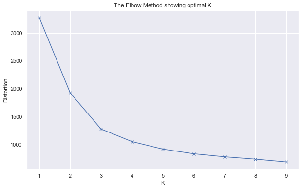

```python
# elbow method to find the optimal K for clustering on pre-processed dataset
distortion =[] # within cluster variance
K = range(1,10) # k ranges for the elbow method

for k in K:
    kmeanModel = KMeans(n_clusters=k) # initiating KMeans algorithm
    kmeanModel.fit(dfTransformed) # fit model to the scaled dataset
    distortion.append(kmeanModel.inertia_)# append within cluster variance value

# plot elbow
plt.figure(figsize=(10,6))
plt.plot(K,distortion,'bx-')
plt.xlabel('K')
plt.ylabel('Distortion')
plt.title('The Elbow Method showing optimal K')
plt.show();
```

**The Elbow method indicated that there are three (3) clusters**

```python
# take k=3 as the number of clusters
kmeansModel_1=KMeans(3)
kmeansModel_1.fit(dfTransformed)
prediction=kmeansModel_1.predict(dfTransformed)

#Append the prediction
df_new = dfBankCustBase_1.copy()
df_new["Labels"] = prediction
dfTransformed['Labels'] = prediction
print("Cluster labels Assigned : \n")
df_new.head(10)
```

```
Cluster labels Assigned :
```

|  | Customer Key | Avg_Credit_Limit | Total_Credit_Cards | Total_visits_bank | Total_visits_online | Total_calls_made | Labels |
| --- | --- | --- | --- | --- | --- | --- | --- |
| 0 | 87073 | 100000 | 2 | 1 | 1 | 0 | 0 |
| 1 | 38414 | 50000 | 3 | 0 | 10 | 9 | 1 |
| 2 | 17341 | 50000 | 7 | 1 | 3 | 4 | 2 |
| 3 | 40496 | 30000 | 5 | 1 | 1 | 4 | 0 |
| 4 | 47437 | 100000 | 6 | 0 | 12 | 3 | 2 |
| 5 | 58634 | 20000 | 3 | 0 | 1 | 8 | 1 |
| 6 | 48370 | 100000 | 5 | 0 | 11 | 2 | 2 |
| 7 | 37376 | 15000 | 3 | 0 | 1 | 1 | 1 |
| 8 | 82490 | 5000 | 2 | 0 | 2 | 2 | 1 |
| 9 | 44770 | 3000 | 4 | 0 | 1 | 7 | 1 |

**3.1.3 K-Means clustering of PCA dataset**

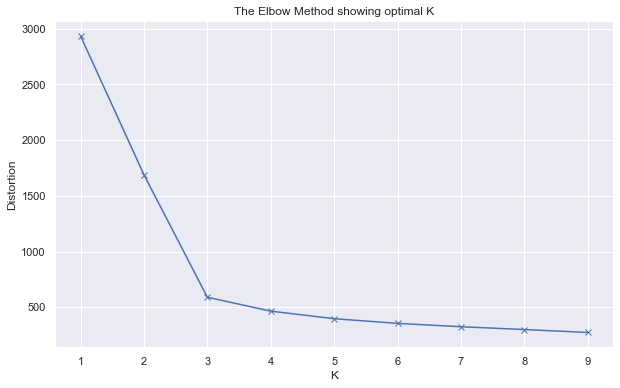

```python
# elbow method to find the optimal K for clustering for PCA dataset
distortion =[] # within cluster variance
K = range(1,10) # k ranges for the elbow method

for k in K:
    kmeanModel = KMeans(n_clusters=k) # initiating KMeans algorithm
    kmeanModel.fit(df_pca) # fit model to the scaled dataset
    distortion.append(kmeanModel.inertia_)# append within cluster variance value

# plot elbow
plt.figure(figsize=(10,6))
plt.plot(K,distortion,'bx-')
plt.xlabel('K')
plt.ylabel('Distortion')
plt.title('The Elbow Method showing optimal K')
plt.show();
```

**The Elbow method indicated that there are three (3) clusters**

```python
# take k=3 as the number of clusters
kmeansModel_1=KMeans(3)
kmeansModel_1.fit(df_pca)
prediction=kmeansModel_1.predict(df_pca)

#Append the prediction
df_pca3 = dfBankCustBase_1.copy()
df_pca3["Labels"] = prediction
df_pca3['Labels'] = prediction
print("Cluster labels Assigned : \n")
df_pca3.head(10)
```

```
Cluster labels Assigned :
```

|  | Customer Key | Avg_Credit_Limit | Total_Credit_Cards | Total_visits_bank | Total_visits_online | Total_calls_made | Labels |
| --- | --- | --- | --- | --- | --- | --- | --- |
| 0 | 87073 | 100000 | 2 | 1 | 1 | 0 | 0 |
| 1 | 38414 | 50000 | 3 | 0 | 10 | 9 | 1 |
| 2 | 17341 | 50000 | 7 | 1 | 3 | 4 | 0 |
| 3 | 40496 | 30000 | 5 | 1 | 1 | 4 | 0 |
| 4 | 47437 | 100000 | 6 | 0 | 12 | 3 | 2 |
| 5 | 58634 | 20000 | 3 | 0 | 1 | 8 | 1 |
| 6 | 48370 | 100000 | 5 | 0 | 11 | 2 | 2 |
| 7 | 37376 | 15000 | 3 | 0 | 1 | 1 | 1 |
| 8 | 82490 | 5000 | 2 | 0 | 2 | 2 | 1 |
| 9 | 44770 | 3000 | 4 | 0 | 1 | 7 | 1 |

**3.2 Analyze cluster formation using Boxplot for K-Means clustering**

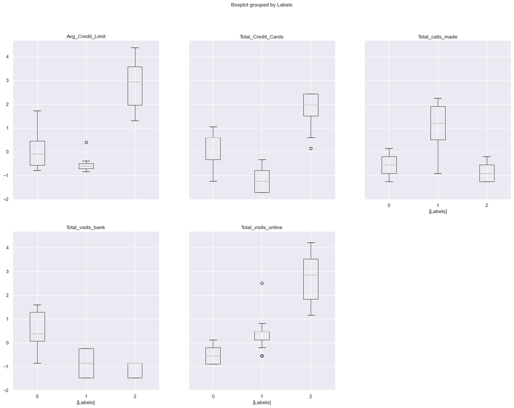

```python
# boxplot of the dataframe dfScaled
dfScaled.boxplot(by ='Labels', layout=(2,3),figsize=(20,15))
plt.show();
```

**CLUSTER 0**

1. They have average credit limit with average number of credit cards
2. They have made average number of calls to the bank as they have visited the most to the bank and have the lowest online presence amongst the groups

**CLUSTER 1**

1. They have the lowest credit limit amongst the customers and lowest number of credit cards
2. They are the ones with the highest number of calls made to the bank and have average visits to the bank and average online presence.

**CLUSTER 2**

1. They have the maximum credit limit amongst the customers with the highest number of credit cards
2. They have made the lowest number of calls to the bank and the lowest visits to the bank but highest online presence.

## Deliverable – 4: Hierarchical clustering (15 marks)

Execute hierarchical clustering(with different linkages) with the help of dendrogram and cophenetic coefficient. Analyze clusters formed using boxplot

1. Check the Cophenetic correlation to find the linkage option with the best results
2. Execute the Hierarchical clustering
3. Plot the Dendrogram using the best linkage option
4. Find the cluster labels and add to the dataset
5. Plot the boxplot and analyze the clusters formed based on the boxplots

**4.1 Calculate the Cophenetic Correlation of the Hierarchical cluster formation using different linkages.**

```python
# import appropriate package for hierarchical clustering
from sklearn.cluster import AgglomerativeClustering
from scipy.cluster.hierarchy import cophenet, linkage, dendrogram
from scipy.spatial.distance import pdist
```

```python
# calulate the cophenetic correlation of linkage ='Average'
z = linkage(dfScaled_1, metric='euclidean',method='average')
c, coph_dists = cophenet(z, pdist(dfScaled_1))

# capture the cophenetic correlation in a dataframe
coph_corr_df = pd.DataFrame({'Linkage Method':['Average'],'Cophenetic corr':c})
coph_corr_df
```

|  | Linkage Method | Cophenetic corr |
| --- | --- | --- |
| 0 | Average | 0.897106 |

```python
# calulate the cophenetic correlation of linkage ='Ward'
z = linkage(dfScaled_1, metric='euclidean',method='ward')
c, coph_dists = cophenet(z, pdist(dfScaled_1))

# capture the cophenetic correlation in a dataframe
coph_corr_df = coph_corr_df.append({'Linkage Method':'Ward','Cophenetic corr':c}
                                   ,ignore_index=True)
coph_corr_df
```

|  | Linkage Method | Cophenetic corr |
| --- | --- | --- |
| 0 | Average | 0.897106 |
| 1 | Ward | 0.741659 |

```python
# calulate the cophenetic correlation of linkage ='Single'
z = linkage(dfScaled_1, metric='euclidean',method='single')
c, coph_dists = cophenet(z, pdist(dfScaled_1))

# capture the cophenetic correlation in a dataframe
coph_corr_df = coph_corr_df.append({'Linkage Method':'Single','Cophenetic corr':c}
                                   ,ignore_index=True)
coph_corr_df
```

|  | Linkage Method | Cophenetic corr |
| --- | --- | --- |
| 0 | Average | 0.897106 |
| 1 | Ward | 0.741659 |
| 2 | Single | 0.739147 |

```python
# calulate the cophenetic correlation of linkage ='Complete'
z = linkage(dfScaled_1, metric='euclidean',method='complete')
c, coph_dists = cophenet(z, pdist(dfScaled_1))


# capture the cophenetic correlation in a dataframe
coph_corr_df = coph_corr_df.append({'Linkage Method':'Complete','Cophenetic corr':c}
                                   ,ignore_index=True)
coph_corr_df
```

|  | Linkage Method | Cophenetic corr |
| --- | --- | --- |
| 0 | Average | 0.897106 |
| 1 | Ward | 0.741659 |
| 2 | Single | 0.739147 |
| 3 | Complete | 0.875802 |

```python
# calulate the cophenetic correlation of linkage ='Average' for outliers treated, transformed and scaled dataset
z = linkage(dfTransformed_1, metric='euclidean',method='average')
c, coph_dists = cophenet(z, pdist(dfTransformed_1))

# capture the cophenetic correlation in a dataframe
coph_corr_df = coph_corr_df.append({'Linkage Method':'Avg_Pre Processed','Cophenetic corr':c}
                                   ,ignore_index=True)
coph_corr_df
```

|  | Linkage Method | Cophenetic corr |
| --- | --- | --- |
| 0 | Average | 0.897106 |
| 1 | Ward | 0.741659 |
| 2 | Single | 0.739147 |
| 3 | Complete | 0.875802 |
| 4 | Avg_Pre Processed | 0.830736 |

```python
# calulate the cophenetic correlation of linkage ='Average' for PCA dataset
z = linkage(df_pca_1, metric='euclidean',method='average')
c, coph_dists = cophenet(z, pdist(df_pca_1))

# capture the cophenetic correlation in a dataframe
coph_corr_df = coph_corr_df.append({'Linkage Method':'Avg_PCA','Cophenetic corr':c}
                                   ,ignore_index=True)
coph_corr_df
```

|  | Linkage Method | Cophenetic corr |
| --- | --- | --- |
| 0 | Average | 0.897106 |
| 1 | Ward | 0.741659 |
| 2 | Single | 0.739147 |
| 3 | Complete | 0.875802 |
| 4 | Avg_Pre Processed | 0.830736 |
| 5 | Avg_PCA | 0.902801 |

**The Cophenetic correlation is high for the Scaled dataset and PCA dataset with linkage as 'Average', with very slight difference.**

Since the K-Means produced better results with scaled dataset, we will also use the same dataset for Hierarchical clustering analysis and use the linkage between clusters as 'Average' </b>

**4.2 Execute the Hierarchical clustering**

**The optimum value of K is 3, which is the number of clusters to be formed and is derived from the Elbow method of K-Means clustering.**

```python
# fit the model for agglomerative hierarchical clustering
hierarchical_model = AgglomerativeClustering(n_clusters=3, affinity='euclidean',  linkage='average')
hierarchical_model.fit(dfScaled_1)
```

```
AgglomerativeClustering(linkage='average', n_clusters=3)
```

```python
# add the labels of clusters to the dfScaled dataset
dfScaled_1['Labels'] = hierarchical_model.labels_
dfScaled_1.head(10)
```

|  | Avg_Credit_Limit | Total_Credit_Cards | Total_visits_bank | Total_visits_online | Total_calls_made | Labels |
| --- | --- | --- | --- | --- | --- | --- |
| 0 | 1.732369 | -1.249105 | -0.860646 | -0.550400 | -1.256040 | 0 |
| 1 | 0.406101 | -0.788168 | -1.475392 | 2.510549 | 1.901468 | 2 |
| 2 | 0.406101 | 1.055582 | -0.860646 | 0.129811 | 0.147297 | 0 |
| 3 | -0.124406 | 0.133707 | -0.860646 | -0.550400 | 0.147297 | 2 |
| 4 | 1.732369 | 0.594644 | -1.475392 | 3.190759 | -0.203537 | 1 |
| 5 | -0.389659 | -0.788168 | -1.475392 | -0.550400 | 1.550634 | 2 |
| 6 | 1.732369 | 0.133707 | -1.475392 | 2.850654 | -0.554372 | 1 |
| 7 | -0.522286 | -0.788168 | -1.475392 | -0.550400 | -0.905206 | 2 |
| 8 | -0.787540 | -1.249105 | -1.475392 | -0.210294 | -0.554372 | 2 |
| 9 | -0.840590 | -0.327230 | -1.475392 | -0.550400 | 1.199799 | 2 |

```python
# check the labels of clusters formed by hierarchical clustering
hierarchical_model.labels_
```

```
array([0, 2, 0, 2, 1, 2, 1, 2, 2, 2, 2, 2, 2, 2, 2, 2, 2, 2, 2, 2, 2, 2,
       2, 2, 2, 2, 2, 2, 2, 2, 2, 2, 2, 2, 2, 2, 2, 2, 2, 2, 2, 2, 2, 2,
       2, 2, 2, 2, 2, 2, 2, 2, 2, 2, 2, 2, 2, 2, 2, 2, 2, 2, 2, 2, 2, 2,
       2, 2, 2, 2, 2, 2, 2, 2, 2, 2, 2, 2, 2, 2, 2, 2, 2, 2, 2, 2, 2, 2,
       2, 2, 2, 2, 2, 2, 2, 2, 2, 2, 2, 2, 2, 2, 2, 2, 2, 2, 2, 2, 2, 2,
       2, 2, 2, 2, 2, 2, 2, 2, 2, 2, 2, 2, 2, 2, 2, 2, 2, 2, 2, 2, 2, 2,
       2, 2, 2, 2, 2, 2, 2, 2, 2, 2, 2, 2, 2, 2, 2, 2, 2, 2, 2, 2, 2, 2,
       2, 2, 2, 2, 2, 2, 2, 2, 2, 2, 2, 2, 2, 2, 2, 2, 2, 2, 2, 2, 2, 2,
       2, 2, 2, 2, 2, 2, 2, 2, 2, 2, 2, 2, 2, 2, 2, 2, 2, 2, 2, 2, 2, 2,
       2, 2, 2, 2, 2, 2, 2, 2, 2, 2, 2, 2, 2, 2, 2, 2, 2, 2, 2, 2, 2, 2,
       2, 2, 2, 2, 2, 2, 0, 0, 0, 0, 0, 0, 0, 0, 0, 0, 0, 0, 0, 0, 0, 0,
       0, 0, 0, 0, 0, 0, 0, 0, 0, 0, 0, 0, 0, 0, 0, 0, 0, 0, 0, 0, 0, 0,
       0, 0, 0, 0, 0, 0, 0, 0, 0, 0, 0, 0, 0, 0, 0, 0, 0, 0, 0, 0, 0, 0,
       0, 0, 0, 0, 0, 0, 0, 0, 0, 0, 0, 0, 0, 0, 0, 0, 0, 0, 0, 0, 0, 0,
       0, 0, 0, 0, 0, 0, 0, 0, 0, 0, 0, 0, 0, 0, 0, 0, 0, 0, 0, 0, 0, 0,
       0, 0, 0, 0, 0, 0, 0, 0, 0, 0, 0, 0, 0, 0, 0, 0, 0, 0, 0, 0, 0, 0,
       0, 0, 0, 0, 0, 0, 0, 0, 0, 0, 0, 0, 0, 0, 0, 0, 0, 0, 0, 0, 0, 0,
       0, 0, 0, 0, 0, 0, 0, 0, 0, 0, 0, 0, 0, 0, 0, 0, 0, 0, 0, 0, 0, 0,
       0, 0, 0, 0, 0, 0, 0, 0, 0, 0, 0, 0, 0, 0, 0, 0, 0, 0, 0, 0, 0, 0,
       0, 0, 0, 0, 0, 0, 0, 0, 0, 0, 0, 0, 0, 0, 0, 0, 0, 0, 0, 0, 0, 0,
       0, 0, 0, 0, 0, 0, 0, 0, 0, 0, 0, 0, 0, 0, 0, 0, 0, 0, 0, 0, 0, 0,
       0, 0, 0, 0, 0, 0, 0, 0, 0, 0, 0, 0, 0, 0, 0, 0, 0, 0, 0, 0, 0, 0,
       0, 0, 0, 0, 0, 0, 0, 0, 0, 0, 0, 0, 0, 0, 0, 0, 0, 0, 0, 0, 0, 0,
       0, 0, 0, 0, 0, 0, 0, 0, 0, 0, 0, 0, 0, 0, 0, 0, 0, 0, 0, 0, 0, 0,
       0, 0, 0, 0, 0, 0, 0, 0, 0, 0, 0, 0, 0, 0, 0, 0, 0, 0, 0, 0, 0, 0,
       0, 0, 0, 0, 0, 0, 0, 0, 0, 0, 0, 0, 0, 0, 0, 0, 0, 0, 0, 0, 0, 0,
       0, 0, 0, 0, 0, 0, 0, 0, 0, 0, 0, 0, 0, 0, 0, 0, 0, 0, 0, 0, 0, 0,
       0, 0, 0, 0, 0, 0, 0, 0, 0, 0, 0, 0, 0, 1, 1, 1, 1, 1, 1, 1, 1, 1,
       1, 1, 1, 1, 1, 1, 1, 1, 1, 1, 1, 1, 1, 1, 1, 1, 1, 1, 1, 1, 1, 1,
       1, 1, 1, 1, 1, 1, 1, 1, 1, 1, 1, 1, 1, 1, 1, 1, 1])
```

```python
# centroid of cluster formed for each feature
dfScaled_1.groupby(['Labels']).mean()
```

| Labels | Avg_Credit_Limit | Total_Credit_Cards | Total_visits_bank | Total_visits_online | Total_calls_made |
| --- | --- | --- | --- | --- | --- |
| 0 | -0.023776 | 0.371998 | 0.667394 | -0.553952 | -0.550708 |
| 1 | 2.820969 | 1.857613 | -1.106544 | 2.816644 | -0.877139 |
| 2 | -0.594335 | -1.060162 | -0.902183 | 0.321312 | 1.147648 |

**4.3 Plot the Dendrogram**

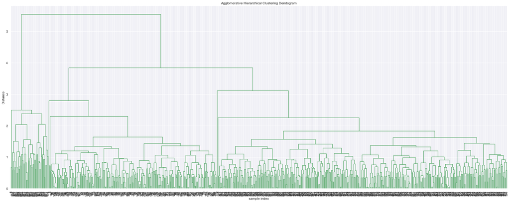

```python
# plot the dendrogram to get execute the agglomerative hierarchical clustering for the cluster formation
# use the dfScaled dataset and linkage method between clusters as 'Average'
z1 = linkage(dfScaled_1, metric='euclidean',method='average')
c, coph_dists = cophenet(z1, pdist(dfScaled_1))

# plot the dendrogram for the full dataset
plt.figure(figsize=(25, 10))
plt.title('Agglomerative Hierarchical Clustering Dendogram')
plt.xlabel('sample index')
plt.ylabel('Distance')
dendrogram(z1, leaf_rotation=90.,color_threshold=90,  leaf_font_size=10. )
plt.tight_layout()
```

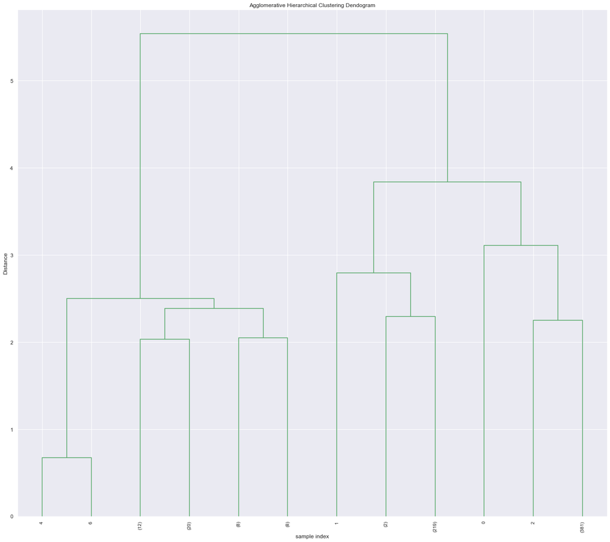

```python
# plot the dendrogram for aesthetics to show the formation of clusters
plt.figure(figsize=(18, 16))
plt.title('Agglomerative Hierarchical Clustering Dendogram')
plt.xlabel('sample index')
plt.ylabel('Distance')
Z = linkage(dfScaled_1, 'average')
dendrogram(Z,leaf_rotation=90.0,p=3,color_threshold=52,leaf_font_size=10,truncate_mode='level')
plt.tight_layout()
```

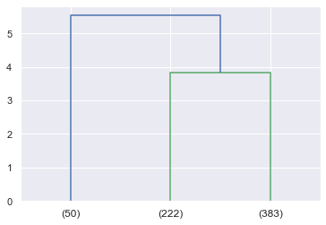

```python
# check the distance at which 3 clusters are formed
dendrogram(Z, truncate_mode='lastp', p = 3) # p is not number of final clusters, but to find the 3 clusters
plt.show()
```

```python
# max dendrogramic distance at which 3 clusters are formed
max_d = 3.83

from scipy.cluster.hierarchy import fcluster
clusters = fcluster(Z, max_d, criterion = 'distance')
clusters
```

```
array([3, 2, 3, 2, 1, 2, 1, 2, 2, 2, 2, 2, 2, 2, 2, 2, 2, 2, 2, 2, 2, 2,
       2, 2, 2, 2, 2, 2, 2, 2, 2, 2, 2, 2, 2, 2, 2, 2, 2, 2, 2, 2, 2, 2,
       2, 2, 2, 2, 2, 2, 2, 2, 2, 2, 2, 2, 2, 2, 2, 2, 2, 2, 2, 2, 2, 2,
       2, 2, 2, 2, 2, 2, 2, 2, 2, 2, 2, 2, 2, 2, 2, 2, 2, 2, 2, 2, 2, 2,
       2, 2, 2, 2, 2, 2, 2, 2, 2, 2, 2, 2, 2, 2, 2, 2, 2, 2, 2, 2, 2, 2,
       2, 2, 2, 2, 2, 2, 2, 2, 2, 2, 2, 2, 2, 2, 2, 2, 2, 2, 2, 2, 2, 2,
       2, 2, 2, 2, 2, 2, 2, 2, 2, 2, 2, 2, 2, 2, 2, 2, 2, 2, 2, 2, 2, 2,
       2, 2, 2, 2, 2, 2, 2, 2, 2, 2, 2, 2, 2, 2, 2, 2, 2, 2, 2, 2, 2, 2,
       2, 2, 2, 2, 2, 2, 2, 2, 2, 2, 2, 2, 2, 2, 2, 2, 2, 2, 2, 2, 2, 2,
       2, 2, 2, 2, 2, 2, 2, 2, 2, 2, 2, 2, 2, 2, 2, 2, 2, 2, 2, 2, 2, 2,
       2, 2, 2, 2, 2, 2, 3, 3, 3, 3, 3, 3, 3, 3, 3, 3, 3, 3, 3, 3, 3, 3,
       3, 3, 3, 3, 3, 3, 3, 3, 3, 3, 3, 3, 3, 3, 3, 3, 3, 3, 3, 3, 3, 3,
       3, 3, 3, 3, 3, 3, 3, 3, 3, 3, 3, 3, 3, 3, 3, 3, 3, 3, 3, 3, 3, 3,
       3, 3, 3, 3, 3, 3, 3, 3, 3, 3, 3, 3, 3, 3, 3, 3, 3, 3, 3, 3, 3, 3,
       3, 3, 3, 3, 3, 3, 3, 3, 3, 3, 3, 3, 3, 3, 3, 3, 3, 3, 3, 3, 3, 3,
       3, 3, 3, 3, 3, 3, 3, 3, 3, 3, 3, 3, 3, 3, 3, 3, 3, 3, 3, 3, 3, 3,
       3, 3, 3, 3, 3, 3, 3, 3, 3, 3, 3, 3, 3, 3, 3, 3, 3, 3, 3, 3, 3, 3,
       3, 3, 3, 3, 3, 3, 3, 3, 3, 3, 3, 3, 3, 3, 3, 3, 3, 3, 3, 3, 3, 3,
       3, 3, 3, 3, 3, 3, 3, 3, 3, 3, 3, 3, 3, 3, 3, 3, 3, 3, 3, 3, 3, 3,
       3, 3, 3, 3, 3, 3, 3, 3, 3, 3, 3, 3, 3, 3, 3, 3, 3, 3, 3, 3, 3, 3,
       3, 3, 3, 3, 3, 3, 3, 3, 3, 3, 3, 3, 3, 3, 3, 3, 3, 3, 3, 3, 3, 3,
       3, 3, 3, 3, 3, 3, 3, 3, 3, 3, 3, 3, 3, 3, 3, 3, 3, 3, 3, 3, 3, 3,
       3, 3, 3, 3, 3, 3, 3, 3, 3, 3, 3, 3, 3, 3, 3, 3, 3, 3, 3, 3, 3, 3,
       3, 3, 3, 3, 3, 3, 3, 3, 3, 3, 3, 3, 3, 3, 3, 3, 3, 3, 3, 3, 3, 3,
       3, 3, 3, 3, 3, 3, 3, 3, 3, 3, 3, 3, 3, 3, 3, 3, 3, 3, 3, 3, 3, 3,
       3, 3, 3, 3, 3, 3, 3, 3, 3, 3, 3, 3, 3, 3, 3, 3, 3, 3, 3, 3, 3, 3,
       3, 3, 3, 3, 3, 3, 3, 3, 3, 3, 3, 3, 3, 3, 3, 3, 3, 3, 3, 3, 3, 3,
       3, 3, 3, 3, 3, 3, 3, 3, 3, 3, 3, 3, 3, 1, 1, 1, 1, 1, 1, 1, 1, 1,
       1, 1, 1, 1, 1, 1, 1, 1, 1, 1, 1, 1, 1, 1, 1, 1, 1, 1, 1, 1, 1, 1,
       1, 1, 1, 1, 1, 1, 1, 1, 1, 1, 1, 1, 1, 1, 1, 1, 1], dtype=int32)
```

**For the Agglomerative Hierarchical clustering, 3 clusters are formed at a dendrogramic distance of 3.83**

**4.4 Analyze cluster formation using Boxplot for Agglomerative Hierarchical clustering**

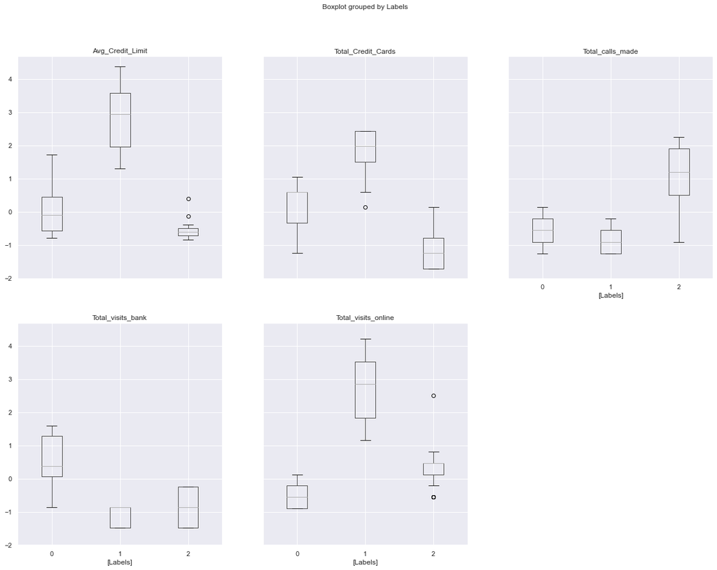

```python
# plot boxplot for hierarchical clustering
dfScaled_1.boxplot(by ='Labels', layout=(2,3),figsize=(20,15))
plt.show();
```

**CLUSTER 0**

1. They have average credit limit with average number of credit cards
2. They have made average number of calls to the bank as they have visited the most to the bank and have the lowest online presence amongst the groups

**CLUSTER 1**

1. They have the maximum credit limit amongst the customers with the highest number of credit cards
2. They have made the lowest number of calls to the bank and the lowest visits to the bank but highest online presence.

**CLUSTER 2**

1. They have the lowest credit limit amongst the customers and lowest number of credit cards
2. They are the ones with the highest number of calls made to the bank and have average visits to the bank and average online presence.

## Deliverable – 5: Calculate average Silhouette coefficient (5 marks)

Calculate average silhouette score for both methods.

**5.1 Silhouette coefficient for K-Means clustering**

```python
# silhouette coefficient for the scaled dataset
from sklearn.metrics import silhouette_score

sil_coeff_scaled = silhouette_score(dfScaled.drop('Labels',axis=1),dfScaled['Labels'])

# create a dataframe to capture the silhouette score of K-Means clustering
sil_coeff_df = pd.DataFrame({'Data Model':['Scaled Only K-Means'],'Silhouette Coeff':sil_coeff_scaled})
sil_coeff_df
```

|  | Data Model | Silhouette Coeff |
| --- | --- | --- |
| 0 | Scaled Only K-Means | 0.515466 |

```python
# silhouette coefficient for the scaled,transformed and outlier treated dataset
sil_coeff_transformed = silhouette_score(dfTransformed.drop('Labels',axis=1),dfTransformed['Labels'])

# create a dataframe to capture the silhouette score of K-Means clustering
sil_coeff_df = sil_coeff_df.append({'Data Model':'Pre Processed K-Means','Silhouette Coeff':sil_coeff_transformed}
                                   ,ignore_index=True)
sil_coeff_df
```

|  | Data Model | Silhouette Coeff |
| --- | --- | --- |
| 0 | Scaled Only K-Means | 0.515466 |
| 1 | Pre Processed K-Means | 0.456443 |

```python
# silhouette coefficient for pca dataset
sil_coeff_pca = silhouette_score(df_pca3.drop('Labels',axis=1),df_pca3['Labels'])

# create a dataframe to capture the silhouette score of K-Means clustering
sil_coeff_df = sil_coeff_df.append({'Data Model':'PCA K-Means','Silhouette Coeff':sil_coeff_pca}
                                   ,ignore_index=True)
sil_coeff_df
```

|  | Data Model | Silhouette Coeff |
| --- | --- | --- |
| 0 | Scaled Only K-Means | 0.515466 |
| 1 | Pre Processed K-Means | 0.456443 |
| 2 | PCA K-Means | 0.105213 |

**5.2 Silhouette coefficient for Hierarchical clustering**

```python
# silhouette coefficient for agglomerative hierarchical clustering
sil_coeff_hierarchical = silhouette_score(dfScaled_1.drop('Labels',axis=1),dfScaled_1['Labels'])

# create a dataframe to capture the silhouette score of K-Means clustering
sil_coeff_df = sil_coeff_df.append({'Data Model':'Hierarchical','Silhouette Coeff':sil_coeff_hierarchical}
                                   ,ignore_index=True)
sil_coeff_df
```

|  | Data Model | Silhouette Coeff |
| --- | --- | --- |
| 0 | Scaled Only K-Means | 0.515466 |
| 1 | Pre Processed K-Means | 0.456443 |
| 2 | PCA K-Means | 0.105213 |
| 3 | Hierarchical | 0.515028 |

**The best silhouette coefficient is given by the Scaled only data K-Means clustering and the Scaled only data Hierarchical clustering.**

## Deliverable – 6: K-Means clusters vs Hierarchical clusters (5 marks)

Compare K-means clusters with Hierarchical clusters.

```python
# silhouette coefficient for the clustering techniques
sil_coeff_df
```

|  | Data Model | Silhouette Coeff |
| --- | --- | --- |
| 0 | Scaled Only K-Means | 0.515466 |
| 1 | Pre Processed K-Means | 0.456443 |
| 2 | PCA K-Means | 0.105213 |
| 3 | Hierarchical | 0.515028 |

**The Silhouette coefficient for both K-Means clustering technique and Agglomerative Hierarchical clustering for the same dataset is identical to three decimal places.**

**Cluster analysis of K-Means Clustering**

**CLUSTER 0**

1. They have average credit limit with average number of credit cards
2. They have made average number of calls to the bank as they have visited the most to the bank and have the lowest online presence amongst the groups

**CLUSTER 1**

1. They have the lowest credit limit amongst the customers and lowest number of credit cards
2. They are the ones with the highest number of calls made to the bank and have average visits to the bank and average online presence.

**CLUSTER 2**

1. They have the maximum credit limit amongst the customers with the highest number of credit cards
2. They have made the lowest number of calls to the bank and the lowest visits to the bank but highest online presence.

**Cluster analysis of Agglomerative Hierarchical Clustering**

**CLUSTER 0**

1. They have average credit limit with average number of credit cards
2. They have made average number of calls to the bank as they have visited the most to the bank and have the lowest online presence amongst the groups

**CLUSTER 1**

1. They have the maximum credit limit amongst the customers with the highest number of credit cards
2. They have made the lowest number of calls to the bank and the lowest visits to the bank but highest online presence.

**CLUSTER 2**

1. They have the lowest credit limit amongst the customers and lowest number of credit cards
2. They are the ones with the highest number of calls made to the bank and have average visits to the bank and average online presence.

**Comparison between K-Means clusters formed versus Hierarchical clusters formed**

1. Both K-Means clustering and Hierarchical clustering yield the same mean Silhouette coefficient score.
2. Cluster 0 of K-Means is similar to Cluster 0 of Hierarchical
3. Cluster 1 of K-Means is similar to Cluster 2 of Hierarchical
4. Cluster 2 of K-Means is similar to Cluster 1 of Hierarchical

## Deliverable – 7: Cluster formation analysis (10 marks)

Analysis the clusters formed, tell us how is one cluster different from another and answer all the key questions.

**7.1 Visualization of clusters formed using K-Means**

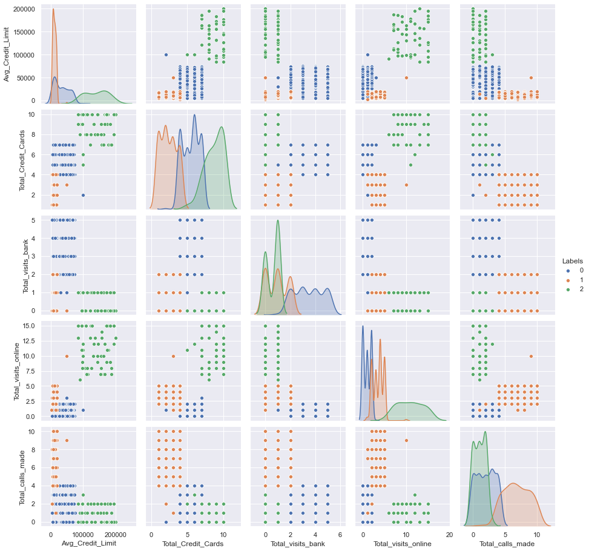

```python
# plot the pairplot between variables with diagonal as KDE using labels generated in K-Means clustering
plt.figure(figsize=(8,8))
sns.pairplot(dfBankCustBase_1.drop('Customer Key',axis=1), diag_kind='kde',hue='Labels')
plt.show();
```

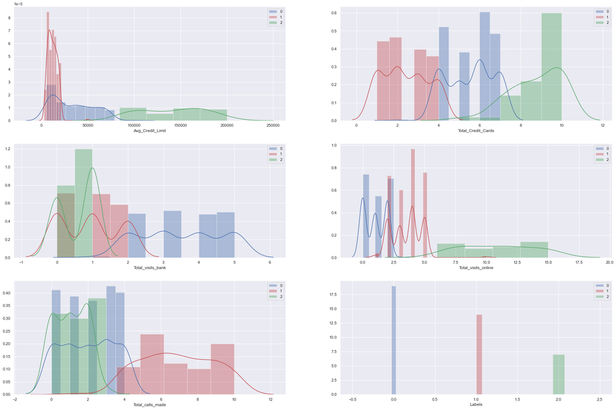

```python
# plotting histogram
plt.figure(figsize=(30,20))
pos = 1
df_review = dfBankCustBase_1.drop('Customer Key',axis=1)
columns = df_review.columns

for i in columns:
    plt.subplot(3,2,pos)
    sns.distplot(df_review[df_review['Labels']==0][i],color='b', label=0)
    sns.distplot(df_review[df_review['Labels']==1][i],color='r', label=1)
    sns.distplot(df_review[df_review['Labels']==2][i],color='g', label=2)
    plt.legend()
    pos += 1
plt.show();
```

```python
# value counts of each clusters formed
df_review['Labels'].value_counts()
```

```
0    383
1    222
2     50
Name: Labels, dtype: int64
```

**7.2 Feature comparison of clusters formed using K-Means indicating differences**

| **Attributes** | Label 0 | Label 1 | Label 2 </b> |
| --- | --- | --- | --- |
| **Avg Credit limit** | Medium | Low | High |
| **Total Credit Cards** | Medium | Low | High |
| **Calls to Bank** | Medium | High | Low |
| **In Person Bank Visits** | High | Medium | Low |
| **Online Visits** | Low | Medium | High |
| **Counts** | 383 | 222 | 50 |

**7.3 Answers to Key questions**

**7.3.1 How many different segments of customers are there?**

There are three(3) segments of customers for the bank based on the data available for analysis

**7.3.2 How are these segments different from each other?**

**Cluster 0** - has customers with average(medium) credit card limit, number of credit cards and calls to the bank. But they visit the bank more frequently but visit online the least. One explanation could be that these customer may not be the most tech savvy customer group.  
**Cluster 1** - has customers with least credit card limit and credit cards, but these customer have the highest calls to the bank and have average visits to the bank or online. Looking at the trends of this group, it seems that this is the group that approaches the bank for support services the most because their queries aren't resolved faster.  
The lower number of credit cards and credit limit would indicate this to be a grieved group with respect to the services provided by the bank.  
**Cluster 2** - has customers with highest credit card limit and number of credit cards. This would indicate that the group is tech savvy and has less grievances with the bank.

**7.3.3 What are your recommendations to the bank on how to better market to and service these customers?**

**Marketing strategy to target new customers and upsell to existing customers**

Assuming that all cluster groups have equal probability of approval for credit products, Clusters-0 and Cluster-1 are potential customer base for upselling to existing customers and attracting new customers if the new customers fall in these clusters

**1. Online Campaigns**

Online campaigns should be primarily targeted to Cluster-1 as the customers of this group have very low credit limit and credit cards but have average online presence.

Cluster-2 can also be targeted for online campaigns as the customers of this group have the highest online visits but this group may lead to increased False Positives because their credit limit is the highest and the group may be saturated and not accept any new products/services/offers.Also, the number of customers belonging to this group are also small.

**2. Offline Campaigns/in-person campaigns**

Cluster-0 should be primarily targeted for offline campaigns as the customers of this group visit the bank often. Cluster-1 can also be considered for offline Campaigns based on their bank visit history.

**3. Improving support services**

Cluster-1 seems to be the group with the most grievance assuming that the contacts made by them to the bank via phone, online and in-person visits is for support services. The operations team should contact Cluster-1 group for considering their feedback for improving the support services and retaining the customer base.